# R Notebook

```r
library(tidyverse)
library(reticulate)
```

# The basics

I’ll use the `diamonds` dataset since it’s available through `ggplot2` (here’s a [description of the fields](https://ggplot2.tidyverse.org/reference/diamonds.html)) and `seaborn`, so there’s lots of examples on both sides of the house. You can also grab it [here](https://vincentarelbundock.github.io/Rdatasets/csv/ggplot2/diamonds.csv).

```python
reticulate::repl_python()
```

```
Python 3.10.0 (/Users/justynrodrigues/Library/r-miniconda/envs/r-reticulate/bin/python)
Reticulate 1.22 REPL -- A Python interpreter in R.
Enter 'exit' or 'quit' to exit the REPL and return to R.
```

```python
#%matplotlib inline
import matplotlib.pyplot as plt
import seaborn as sns
import numpy as np
import pandas as pd
sns.set_style('white')

df = sns.load_dataset('diamonds')
df.head()
```

```
   carat      cut color clarity  depth  table  price     x     y     z
0   0.23    Ideal     E     SI2   61.5   55.0    326  3.95  3.98  2.43
1   0.21  Premium     E     SI1   59.8   61.0    326  3.89  3.84  2.31
2   0.23     Good     E     VS1   56.9   65.0    327  4.05  4.07  2.31
3   0.29  Premium     I     VS2   62.4   58.0    334  4.20  4.23  2.63
4   0.31     Good     J     SI2   63.3   58.0    335  4.34  4.35  2.75
```

And here’s a [cool site on the 4 C’s](https://4cs.gia.edu/en-us/4cs-diamond-quality/) of diamond quality because I know y’all are too lazy to google it!

## Let’s start with `pandas` vs. `dplyr` …

The basic mapping of `dplyr` to `pandas` is:

| `dplyr` | `pandas` |
| --- | --- |
| `mutate` | `assign` |
| `select` | `filter` |
| `rename` | `rename` |
| `filter` | `query` |
| `arrange` | `sort_values` |
| `group_by` | `groupby` |
| `summarize` | `agg` |

There are of course many others (on both sides of the table), but this is a good start.

Next up: the beloved “pipe” operator `%>%` in the Tidyverse (actually due to the `magrittr` package) allows you to turn nested operations into chains, like this:

```r
df_r <- diamonds

# turn this ...
head(filter(select(df_r, carat, color), color == 'E'), 3)
```

```r
# into this ...
df_r %>%
  select(carat, color) %>%
  filter(color == 'E') %>%
  head(3)
```

| carat | color |
| --- | --- |
| 0.23 | E |
| 0.21 | E |
| 0.23 | E |

which is lovely to read. We can achieve the same effect in `pandas` because data is represented as a class instance of `pandas.DataFrame`, so we can do successive method calls like this:

```python
reticulate::repl_python()
```

```
Python 3.10.0 (/Users/justynrodrigues/Library/r-miniconda/envs/r-reticulate/bin/python)
Reticulate 1.22 REPL -- A Python interpreter in R.
Enter 'exit' or 'quit' to exit the REPL and return to R.
```

```python
(df
 .filter(['carat', 'color'])
 .query('color == "E"')
 .head(3))
```

```
   carat color
0   0.23     E
1   0.21     E
2   0.23     E
```

Of note: gotta wrap the whole thing in parantheses (what is this, Lisp?), or else end each line with a backslash (ugh). The quotes in `query` need to be single-outside, double-inside (or the reverse), not all the same. You need to pass a `list` of columns to filter-in (dplyr: select). Everything’s in quotes, all the time, no tidyeval quosures or whatnot here.

Overall though, our mapping is right on track so far.

Let’s try a slightly trickier one.

```r
# dplyr
df_r %>%
  select(starts_with('c')) %>%
  filter(cut %in% c('Ideal', 'Premium')) %>%
  group_by(cut, color, clarity) %>%
  summarise(
    avgcarat = mean(carat, na.rm = TRUE),
    n = n()) %>%
  arrange(desc(avgcarat)) %>%
  head()
```

| cut | color | clarity | avgcarat | n |
| --- | --- | --- | --- | --- |
| Ideal | J | I1 | 1.990000 | 2 |
| Premium | I | I1 | 1.605833 | 24 |
| Premium | J | I1 | 1.578462 | 13 |
| Premium | J | SI2 | 1.554534 | 161 |
| Ideal | H | I1 | 1.475526 | 38 |
| Premium | I | SI2 | 1.424006 | 312 |

… or …

```python
reticulate::repl_python()
```

```
Python 3.10.0 (/Users/justynrodrigues/Library/r-miniconda/envs/r-reticulate/bin/python)
Reticulate 1.22 REPL -- A Python interpreter in R.
Enter 'exit' or 'quit' to exit the REPL and return to R.
```

```python
# python
(df
 .filter(regex='^c')
 .query('cut in ["Ideal", "Premium"]')
 .groupby(['cut', 'color', 'clarity'])
 .agg(['mean', 'size'])
 .sort_values(by=('carat', 'mean'), ascending=False)
 .head())
```

```
                          carat
                           mean size
cut     color clarity
Ideal   J     I1       1.990000    2
Premium I     I1       1.605833   24
        J     I1       1.578462   13
              SI2      1.554534  161
Ideal   H     I1       1.475526   38
```

Not bad, and we are almost exactly one-to-one with `dplyr`, but some things to note:

- We had to resort to regular expressions. We could have replaced the 2nd line with `.filter(df.columns[df.columns.str.startswith('c')])`, but that is definitely worse. Or led off with the slice `(df[df.columns.str.startswith('c')]...)` but that’s clunky *and* ruins the chain pattern. Just learn a little regex I guess?
- The `query` command is really nice and idiomatic (dare I say better???).
- Two things happening behind the scenes of that `agg` command. First, it silently drops non-numeric columns since we asked for a mean, which means just the carat column is left, which is all we wanted anyway. But if, for example, color were numeric, it’d be giving us the means for that column too. The “size” command is analogous to `n()`, and measures the number of rows in a group for a particular column, in this case for carat. This is a bit weird to me, “size” should not be a sub-property of carat, it should be its own column, but there doesn’t appear to be a way to do that (unless you create a dummy column with `.assign(n=1) ... .agg({'n': 'size'}))`.
- We now have a `pandas.MultiIndex` happening in the rows *and* columns. We can get rid of the row multi-index by calling `reset_index()` (helpful later for plotting), similar to `ungroup()` in dplyr, but I’m not sure how to “flatten” the columns in a chain like this. This is what leads to the tuple `('carat', 'mean')` in `sort_values`.

I think this little maneuver captures the essence of the differences between `dplyr` and `pandas`. Basically, pandas can do it, but it’s not “opinionated” about how you do things ([Hadley’s words](https://www.tidyverse.org), not mine) and therefore the way(s) to do it are not as streamlined.

## … and a little `tidy`ing

I think where `ggplot2` really started to sing for me was when I (finally) figured out how “tidy” data worked, and how to employ `tidyr::gather` and `tidyr::spread` in a data wrangle chain.

For example, say we want to plot separate histograms of the x, y, and z columns. Well, we could loop through 3 ggplot commands, specifying a different color each time (this is the base R or matplotlib approach, and honestly I don’t mind it), or we can `gather` the x-y-z columns into *long* format so that each diamond corresponds to 3 rows: one for x, one for y, one for z. Now we have a column designating whether it’s x, y, or z, and a column with the corresponding value. Behold:

```r
# tidyr
df_r %>%
  select(x, y, z) %>%
  gather(key=dim, value=mm) %>%
  head()
```

| dim | mm |
| --- | --- |
| x | 3.95 |
| x | 3.89 |
| x | 4.05 |
| x | 4.20 |
| x | 4.34 |
| x | 3.94 |

which sets us up to do a [“grammar of graphics”](http://vita.had.co.nz/papers/layered-grammar.html)-style plot like this

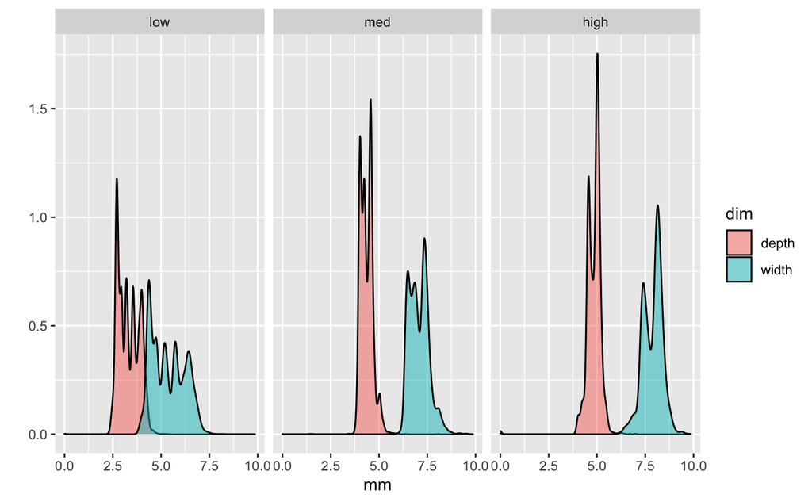

```r
df_r %>%
  mutate(price.cat = cut(price, breaks=3, labels=c('low', 'med', 'high'))) %>%
  select(price.cat, width=x, depth=z) %>%
  gather(key=dim, value=mm, -price.cat) %>%
  filter(mm < 10) %>%
  ggplot(aes(x=mm, fill=dim)) +
  geom_density(alpha=0.5) +
  facet_wrap(~price.cat) +
  ylab('')
```

For `pandas` the equivalent is

| `tidyr` | `pandas` |
| --- | --- |
| `gather` | `melt` |
| `spread` | `pivot` |

Also in the pandas toolbox is `stack` and `unstack`, and `pivot_table`, depending on the structure of the DataFrame. See [this post](http://nikgrozev.com/2015/07/01/reshaping-in-pandas-pivot-pivot-table-stack-and-unstack-explained-with-pictures/) or [the docs](https://pandas.pydata.org/pandas-docs/stable/reshaping.html) for a little more thorough discussion.

Can we reproduce the 9-line beauty from above in `pandas`? Let’s start with the data structure:

```python
(df
 .assign(pricecat = pd.cut(df['price'], bins=3, labels=['low', 'med', 'high']))
 .filter(['x', 'z', 'pricecat'])
 .rename(columns={'x': 'width', 'z': 'depth'})
 .melt(id_vars=['pricecat'], value_vars=['width', 'depth'],
       var_name='dim', value_name='mm')
 .head())
```

[output not shown]

We did it! It’s almost identical! We did have to add a line to rename columns, since `dplyr`’s `select` was cheating by doing double-duty as `rename`. But biggest difference, to me, is that `melt` wants you to specify the list of where information is *coming from*, whereas `tidyr::gather` wants you to specify where the information is *going to*. This is fine by me though, and maybe even makes more sense.

Now to plot it.

# Visualization

First, a straightforward approach. Second, a trick.

## Vanilla

A straightforward thing to do would be to just save the DataFrame and then plot it, for example,

```python
df2 = (df
 .assign(pricecat = pd.cut(df['price'], bins=3, labels=['low', 'med', 'high']))
 .filter(['x', 'z', 'pricecat'])
 .rename(columns={'x': 'width', 'z': 'depth'})
 .melt(id_vars=['pricecat'], value_vars=['width', 'depth'],
       var_name='dim', value_name='mm')
 .query('2 < mm < 10'))

g = sns.FacetGrid(data=df2, col='pricecat', hue='dim')
g.map(sns.kdeplot, 'mm', shade=True, alpha=0.5).add_legend()
```

[output not shown]

## The `pipe` + `seaborn` trick

But we can do better. `pandas.DataFrame` exposes a `pipe` method that allows us to pipe in any method we want. To include: plotting methods.

```python
(df
 .assign(pricecat = pd.cut(df['price'], bins=3, labels=['low', 'med', 'high']))
 .filter(['x', 'z', 'pricecat'])
 .rename(columns={'x': 'width', 'z': 'depth'})
 .melt(id_vars=['pricecat'], value_vars=['width', 'depth'],
       var_name='dim', value_name='mm')
 .query('2 < mm < 10')
 .pipe((sns.FacetGrid, 'data'),
       col='pricecat', hue='dim', height=6)
 .map(sns.kdeplot, 'mm', shade=True, alpha=0.5)
 .add_legend(fontsize=14))
```

I’ll omit the image because it’s essentially identical to the previous. The main trick is the tuple `(sns.FacetGrid, 'data')` that sends the `DataFrame` to the `data` arg of `FacetGrid`.

But how cool is that: this is nearly identical to a tidyverse+ggplot approach, almost line-by-line. Biggest difference is perhaps having to facet first. I am really satisfied that I can wrangle a `DataFrame` and `pipe` it directly into a viz.

Here’s another for good measure, with some longer `query` and `FacetGrid` commands.

```python
(df
 .query('cut in ["Ideal", "Good"] & \
         clarity in ["IF", "SI2"] & \
         carat < 3')
 .pipe((sns.FacetGrid, 'data'),
       row='cut', col='clarity', hue='color',
       hue_order=list('DEFGHIJ'),
       height=6,
       legend_out=True)
 .map(sns.scatterplot, 'carat', 'price', alpha=0.8)
 .add_legend())
```

[output not shown]

# Taking things too far

I’ve said it before and I’ll say it again: sometimes this type of method-chaining feels like trying to line up all the targets perfectly so you can get everything you want with one shot. And yet often it’s easier, nicer, even faster, to just walk over and smash the targets one by one with a hammer. And by hammer I mean matplotlib and a for-loop.

Here’s an example. Let’s say we want to visualize a scatterplot of price vs. carat for all diamonds in the dataset, but highlight the datapoints corresponding to the highest quality combination of cut/clarity. Here’s the most elegant way I can figure to do this as a “one-liner”:

```python
fig, ax = plt.subplots(1,1, figsize=(8,8))
pal = dict(zip(df['color'].unique(), sns.color_palette('Set1', desat=.9)))
pal['Other'] = (1,1,1)

(df
 .assign(nice = np.where((df['cut']=='Ideal') & (df['clarity']=='IF'), df['color'], 'Other'))
 .sort_values(by='nice', ascending=False)
 .pipe((sns.scatterplot, 'data'),
       x='carat', y='price',
       hue='nice', hue_order=np.append('Other', list('DEFGHIJ')),
       palette=pal,
       alpha=0.8,
       edgecolor=(0.92,0.92,0.92),
       ax=ax))
```

[output not shown]

Note the contortions we have to undergo to make this work: a new column with color for the special group and “Other” for others (seems sensible), sort so the “Other” rows are first and thus get plotted first in the scatterplot (hmm a little sketchy but ok nice trick), create a custom palette with white for “Other”, then put a very light edge around all points so we can see the white ones but they’re not distracting.

Exhausting, and in this case, a little silly. Here’s a hammer-smash-bottle approach that creates nearly an identical plot (perhaps an even better one):

```python
df2 = (df
 .assign(nice = np.where((df['cut']=='Ideal') & (df['clarity']=='IF'), df['color'], 'Other')))

fig, ax = plt.subplots(1,1, figsize=(8,8))

ax.scatter(data=df2.query('nice == "Other"'), x='carat', y='price',
           c=[[0.92,0.92,0.92]], s=20, alpha=0.2)

sns.scatterplot(data=df2.query('nice != "Other"'), x='carat', y='price',
                hue='color', hue_order=list('DEFGHIJ'),
                palette='Set1', s=30, alpha=0.9, ax=ax)
```

[output not shown]

So it involved creating a duplicate of `df`, which might be prohibitive for very large or streaming datasets, but it’s way easier to understand, write, debug, etc.

# Parting thoughts

- Nothing requires us to use seaborn, we could have used `matplotlib` in those `pipe` commands. (And `pyplot.scatter` support column name indexing now!) Also, pretty sure you could also use [`Altair`](https://altair-viz.github.io) or other plotting methods as well but I haven’t yet tried.
- Inexperienced musing: `tidyverse` allows a mix of quoted and unquoted references to variable names. In my (in)experience, the convenience this brings is accompanied by equal consternation. It seems to me a lot of the problems solved by [`tidyeval`](http://www.onceupondata.com/2017/08/12/my-first-steps-into-the-world-of-tidyeval/) would not exist if all variables were quoted all the time, as in pandas, but there are likely deeper truths I’m missing here…

Thanks for reading! Feedback [always welcome](https://twitter.com/thestevemo).